# 4th week project

Samir N. Hag Ibrahim

September 15, 2019

# Introduction:

This project is part of the coursera statistical inference course requirement. The project includes two parts: 1. Simulation Exercise 2. ToothGrowth datasets inferetial analysis

# PART ONE: SIMULATION EXERCISE

## General Overview

Investigate the exponential distribution in R and compare it with the Central Limit Theorem. The exponential distribution can be simulated in R with rexp(n, lambda) where lambda is the rate parameter. The mean of exponential distribution is 1/lambda and the standard deviation is also 1/lambda. Set lambda = 0.2 for all of the simulations. You will investigate the distribution of averages of 40 exponentials. Note that you will need to do a thousand simulations.

## Instructions and Requirements

Illustrate via simulation and associated explanatory text the properties of the distribution of the mean of 40 exponentials.

illustrate the followings: 1. Show the *sample mean* and compare it to the *theoretical mean* of the distribution. 2. Show how *variable the sample* is and compare it to the *theoretical variance* of the distribution. 3. Show that the *distribution* is approximately *normal*.

## 1. Show the sample mean and compare it to the theoretical mean of the distribution.

Firs, load the libraries

```r
library(ggplot2)
```

Then, set the variables as defined

```r
lambda <- 0.2
n <- 40
nosim <- 1000
set.seed(1234)
simData <- matrix(rexp(n*nosim, rate = lambda), nosim)
```

Now, calculate the Mean of the simulated data

```r
simMeans <- apply(simData, 1, mean) # calculate the sample rows means
sampleMean <- mean(simMeans)# calculating the overall sample Mean
theorMean <- 1/lambda # theoretical Mean
sampleMean
```

```
## [1] 4.974239
```

```r
theorMean
```

```
## [1] 5
```

the sample means’ distribution was found to be centered at 4.9742388, where the theoretical mean is 5, idicating that both the sample mean and the theoretical mean are almost identical.

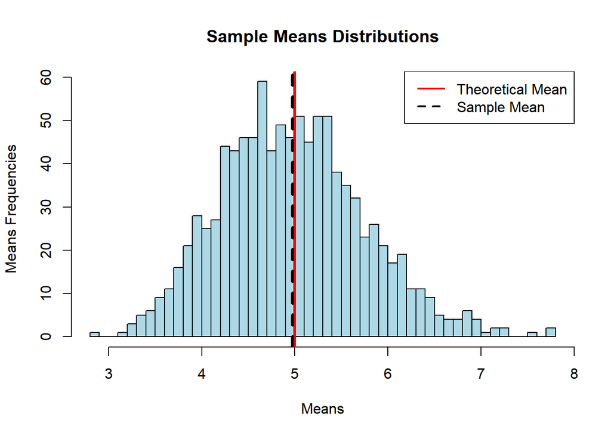

```r
hist(simMeans, breaks = 40, main = "Sample Means Distributions", xlab= "Means", ylab = "Means Frequencies", col = "lightblue")
abline(v = theorMean, lty = 1, lwd = 3, col = "red")
abline(v = sampleMean, lty= 2, lwd = 3, col = "black")
legend("topright", legend = c( "Theoretical Mean", "Sample Mean"),lty = c(1,2) , lwd = 2, col = c("red", "black"))
```

## 2. Show how variable the sample is and compare it to the theoretical variance of the distribution.

in this part, the sample variance will be compared with the theoretical variance reported.

first, calculating the sample variance of the means and the theoretical variance

```r
sampleVar <- var(simMeans)
theorVar <- (1/(lambda)^2/n)
sampleVar
```

```
## [1] 0.5949702
```

```r
theorVar
```

```
## [1] 0.625
```

## 3. Show that the distribution is approximately normal.

```r
sampleSD <- sd(simMeans)
theorSD <- 1/(lambda*sqrt(n))
sampleSD
```

```
## [1] 0.7713431
```

```r
theorSD
```

```
## [1] 0.7905694
```

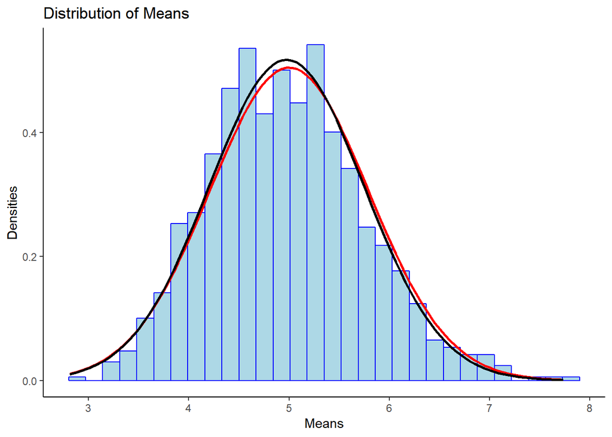

```r
data <- data.frame(simMeans)
m <- ggplot(data, aes(x=simMeans))+
        geom_histogram(aes(y = ..density..), colour = "blue", fill = "lightblue")+
        labs(title = "Distribution of Means", x = "Means", y = "Densities")+
        stat_function(fun = dnorm, args = list(mean = theorMean, sd = theorSD), color = "red", size = 1)+
        stat_function(fun = dnorm, args = list(mean = sampleMean, sd = sampleSD), color = "black", size = 1)+
        theme_classic()
m
```

# PART TWO:BASIC INFERENTIAL DADA ANALYSIS

## General Overview

In this part of the project, we will analyze the dataset ToothGrowth. This dataset is made of 60 observations of tooth growth of Guinea pigs and the effect of dose of vitamin C on the growth. The delivery method is a two-values factor variable : “OJ” (Orange Juice) and VC (Ascorbi Acid, a form of Vitamin C). The dose given contains three different values : 0.5, 1, and 2 mg/day. The measures are done on 10 Guinea pigs.

## Instructions and Requirements

Using the provided data, perform the following tasks: 1. Load the data and perform basic EDA. 2. Provide a basic summary of the data 3. Use confidence intervals and/or hypothesis tests to compare tooth growth by supp and dose. (Only use the techniques from class, even if there’s other approaches worth considering)

## 1. Load the data and perform basic EDA.

first, laod the libraries and the dataset

```r
library(ggplot2)
library(DataExplorer)
library(mlbench)
library(skimr)
library(dplyr)
data("ToothGrowth")
```

EDA is useful to get a glimpse of the provided data. EDA was performed as follow:

### Data Validation and quality

#### A. data structure

```r
str(ToothGrowth)
```

```
## 'data.frame':    60 obs. of  3 variables:
##  $ len : num  4.2 11.5 7.3 5.8 6.4 10 11.2 11.2 5.2 7 ...
##  $ supp: Factor w/ 2 levels "OJ","VC": 2 2 2 2 2 2 2 2 2 2 ...
##  $ dose: num  0.5 0.5 0.5 0.5 0.5 0.5 0.5 0.5 0.5 0.5 ...
```

The dataset is made up of 60 observation and 3 variables.

from the results above we can see that we have 2 numeric variables and 1 categorical variable with two levels (“OJ” and “VC”).

#### B. MIssing Values

```r
sum(is.na(ToothGrowth))
```

```
## [1] 0
```

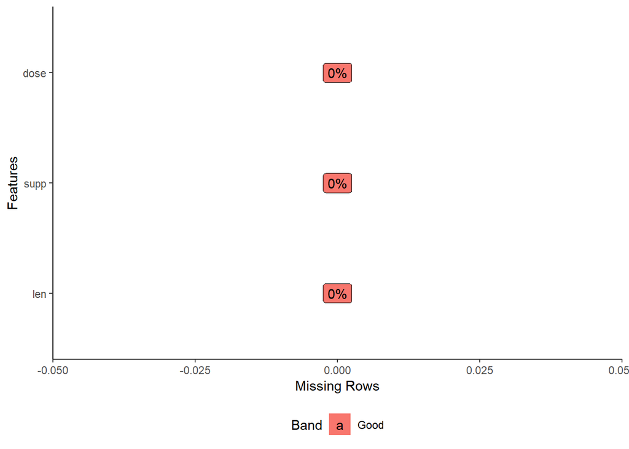

```r
plot_missing(ToothGrowth, ggtheme = theme_classic())
```

Accordingly, there is no missing values in the dataset.

#### C. Data summary

for more details about the dataset

```r
summary(ToothGrowth)
```

```
##       len        supp         dose
##  Min.   : 4.20   OJ:30   Min.   :0.500
##  1st Qu.:13.07   VC:30   1st Qu.:0.500
##  Median :19.25           Median :1.000
##  Mean   :18.81           Mean   :1.167
##  3rd Qu.:25.27           3rd Qu.:2.000
##  Max.   :33.90           Max.   :2.000
```

```r
skim(ToothGrowth)
```

```
## Skim summary statistics
##  n obs: 60
##  n variables: 3
##
## -- Variable type:factor ------------------------------------------------------------------------------
##  variable missing complete  n n_unique            top_counts ordered
##      supp       0       60 60        2 OJ: 30, VC: 30, NA: 0   FALSE
##
## -- Variable type:numeric -----------------------------------------------------------------------------
##  variable missing complete  n  mean   sd  p0   p25   p50   p75 p100
##      dose       0       60 60  1.17 0.63 0.5  0.5   1     2     2
##       len       0       60 60 18.81 7.65 4.2 13.07 19.25 25.27 33.9
##      hist
##  ▇▁▇▁▁▁▁▇
##  ▃▅▃▅▃▇▂▂
```

also, we see that we have 2 numeric variables and 1 factor variable (with 2 levels) each with 60 observation and no missing values recorded.

chacking the frequency of the catergorical variables

```r
with(ToothGrowth, table(supp))
```

```
## supp
## OJ VC
## 30 30
```

we have 30 obervations for each level.

plot the frequencies

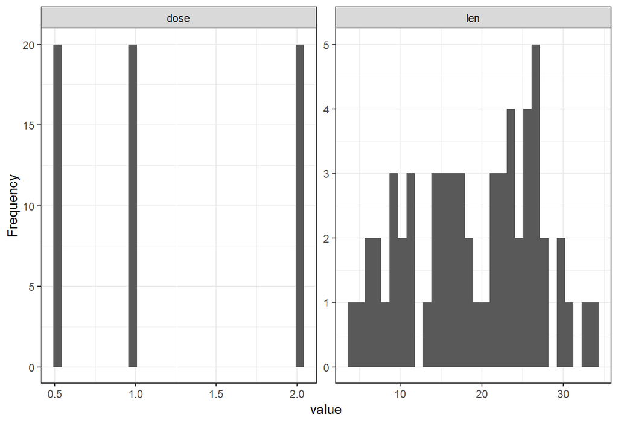

```r
plot_histogram(ToothGrowth, ggtheme = theme_bw())
```

it seems that the dose is a *Factor* variable rather than numeric variable.

converting dose variable into *Factor*.

```r
ToothGrowth$dose <- as.factor(ToothGrowth$dose)
```

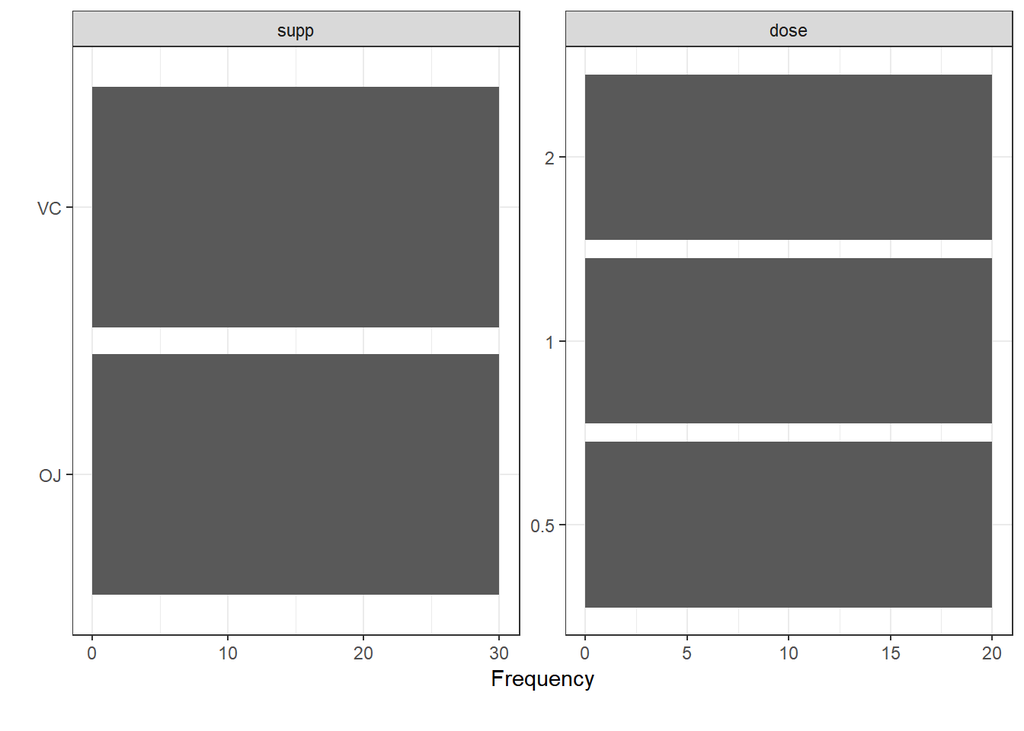

```r
plot_bar(ToothGrowth, ggtheme = theme_bw())
```

Accordingly, we have 2 supp levels (30 obs each) and 3 dose levels (20 obs each). sounds like we have 10 obs per dose for each supp.

```r
table(ToothGrowth$dose, ToothGrowth$supp)
```

```
##
##       OJ VC
##   0.5 10 10
##   1   10 10
##   2   10 10
```

#### D. effect on tooth length

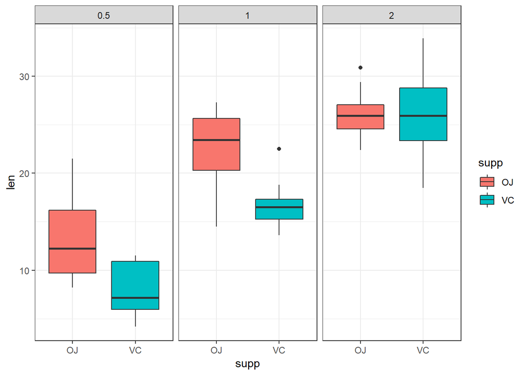

```r
ggplot(ToothGrowth, aes(x = supp, y = len))+
        geom_boxplot(aes(fill = supp))+
        facet_wrap(. ~dose)+
        theme_bw()
```

So, the over all conclusion from EDA is that: 1. There are 3 variables (2 numeric and 1 categorical) 2. *dose* variable was set as a numeric variable where it is actually a *Factor*. 3. There are 10 obs per dose for each supplement. 4. There is no missing values in the data set. 5. Possibly there an effect of dose on the tooth growth, since increasing the dose leads to an increase in the teeth legnth, but it is not yet clear if there is an effect of supplement type on that.

## 2. Provide a basic summary of the data

Here bellow is the statistical summary of the data.

```r
library(pastecs)
summary(ToothGrowth)
```

```
##       len        supp     dose
##  Min.   : 4.20   OJ:30   0.5:20
##  1st Qu.:13.07   VC:30   1  :20
##  Median :19.25           2  :20
##  Mean   :18.81
##  3rd Qu.:25.27
##  Max.   :33.90
```

```r
stat_tooth <- stat.desc(ToothGrowth)
```

## 3. Use confidence intervals and/or hypothesis tests to compare tooth growth by supp and dose

### A- t-test

#### I- Effect of Supplement on Toothgrowth

```r
t.test_supp <- t.test(data=ToothGrowth, len~supp, paired = FALSE)
t.test_supp
```

```
##
##  Welch Two Sample t-test
##
## data:  len by supp
## t = 1.9153, df = 55.309, p-value = 0.06063
## alternative hypothesis: true difference in means is not equal to 0
## 95 percent confidence interval:
##  -0.1710156  7.5710156
## sample estimates:
## mean in group OJ mean in group VC
##         20.66333         16.96333
```

According to the t-test, the p-value forlen by supp was found to be 0.0606345 “i.e. *p>0.05*”, therefore, we can not reject the null hypothesis (i.e. there is no differece between the means).

But since _p -value < 0.1, so, we can not be sure if the we truely can reject the null hypothesis, therefore, the power was calculated in the next section.

#### II- The effect of DOSE on Toothgrowth

Since we have 3 levels for *dose*, we will subset the main dataset into 3 subsets

```r
d1 <- ToothGrowth[ToothGrowth$dose == c(0.5, 1), ]
d2 <- ToothGrowth[ToothGrowth$dose == c(0.5, 2), ]
d3 <- ToothGrowth[ToothGrowth$dose == c(1, 2), ]
```

```r
t.test_d1<- t.test(data = d1, len~dose, paired = FALSE)
t.test_d2<- t.test(data = d2, len~dose, paired = FALSE)
t.test_d3<- t.test(data = d2, len~dose, paired = FALSE)
t.test_dose <- as.data.frame(row.names = "p-value", cbind("Dose 0.5 & 1" = t.test_d1$p.value,"Dose 0.5 & 2" = t.test_d2$p.value, "Dose 1 & 2" = t.test_d3$p.value))
t.test_dose
```

```
##         Dose 0.5 & 1 Dose 0.5 & 2   Dose 1 & 2
## p-value 0.0002951967 9.361615e-07 9.361615e-07
```

### B- power:

*Power* was used here to evaluate the power ( or probability ) of rejecting the null hypothesis “that there is a significant difference between the means of *supp*” under the current test conditions.

first we subset the data based on *supp* valiable.

```r
stat_OJ <- stat.desc(ToothGrowth[ToothGrowth$supp == "OJ", ])
stat_VC <- stat.desc(ToothGrowth[ToothGrowth$supp == "VC", ])
```

*Tets conditions:* number of samples = 30 for each treatment, the difference between the means is 3.7 sd of the data = 7.64

```r
power_supp <- power.t.test(n=30, delta = stat_OJ$len[9]-stat_VC$len[9], sd= stat_tooth$len[13], type = "two.sample", alternative = "one.sided")
power_supp
```

```
##
##      Two-sample t test power calculation
##
##               n = 30
##           delta = 3.7
##              sd = 7.649315
##       sig.level = 0.05
##           power = 0.5818401
##     alternative = one.sided
##
## NOTE: n is number in *each* group
```

Accordingly, under the current stats, there is 58.1840145% probability to reject the null hypothesis (relatively low probability for reject the null hypothesis)

to increase this probability, we have either one of two options: 1- increase the number of samples 2- increase delta (i.e. the means difference)

#### I- Number of samples

in the current dataset, there are 30 observations for each supp variable. However, this number of observations might not be enough to observe a significant difference between the treatment means. the question now: *what is the number of samples required that can increase the probability (up to 80%) for rejecting the null hypothesis???*

```r
power_n <- power.t.test(power = 0.8, delta = stat_OJ$len[9]-stat_VC$len[9], sd = stat_tooth$len[13], type = "two.sample", alternative = "one.sided")
power_n$n
```

```
## [1] 53.5388
```

#### II- Increase delta

Also we can increase the power of rejecting the null hypothesis if the means difference increased. here we are calculating the minimum difference between the means that should be verified in order to have an 80% probability to reject the null hypothesis **“no difference between the means of the treatments”**.

```r
power_delta <- power.t.test(power = 0.8, n=30, sd = stat_tooth$len[13], type = "two.sample", alternative = "one.sided")
power_delta
```

```
##
##      Two-sample t test power calculation
##
##               n = 30
##           delta = 4.969208
##              sd = 7.649315
##       sig.level = 0.05
##           power = 0.8
##     alternative = one.sided
##
## NOTE: n is number in *each* group
```

from the calculations above, we can observe that the mininum value of *delta* at which there is 80 % probability for rejecting the null hypothesis is 4.97. This value is greater that the actual means difference 3.7.

Hence, the only possible way to increase the probability of rejecting the null hypothesis (that there is no significant difference between supplements means), is by increaseing the number os observations up to 54 sample.

#### DONE **********************